# Лабораторная работа №5

Простые сети в GNS3. Анализ трафика

Авдадаев Джамал Геланиевич

19 декабря 2025

# Цель работы

## Основная цель

Построение и исследование простейших сетевых топологий  
в среде моделирования **GNS3** с использованием:

- Ethernet-коммутаторов
- оконечных устройств VPCS
- маршрутизаторов **FRR** и **VyOS**

А также анализ сетевого трафика с помощью **Wireshark**.

# Простая сеть на базе коммутатора

## Топология сети

- Два оконечных устройства VPCS
- Один Ethernet-коммутатор
- Все узлы находятся в одной подсети

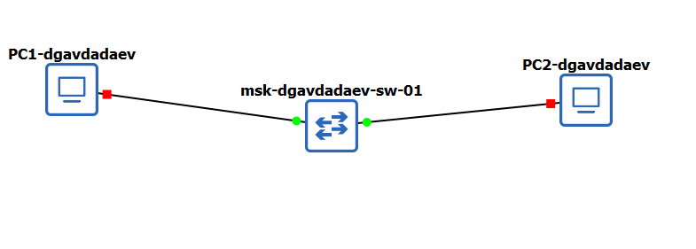

Топология сети

## Анализ ARP

- Зафиксированы gratuitous ARP-запросы
- Используются для:
  - проверки уникальности IP-адреса
  - объявления соответствия IP–MAC
- Передача осуществляется на широковещательный MAC-адрес

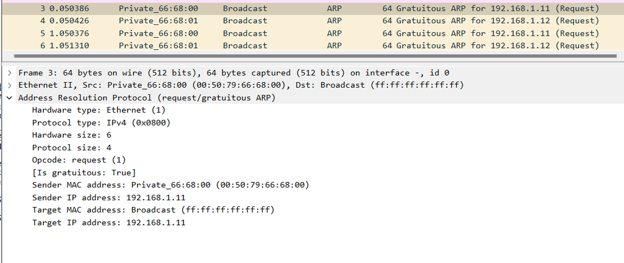

ARP-трафик

## Анализ ICMP

- Выполнены ICMP Echo Request / Reply
- Подтверждена корректная доставка пакетов
- TTL и идентификаторы соответствуют стандарту

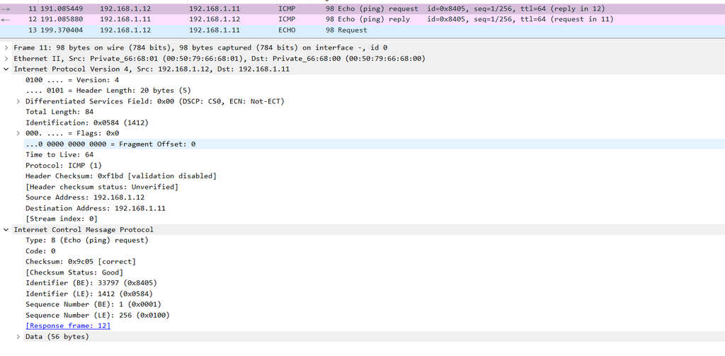

ICMP-трафик

## Анализ UDP

- UDP:
  - отсутствует установление соединения
  - используется порт 7 (Echo)

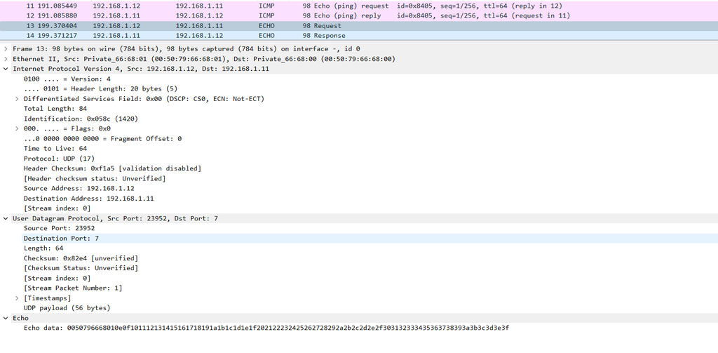

UDP

## Анализ TCP

- TCP:
  - выполнено трёхстороннее рукопожатие
  - передача данных и корректное завершение сессии

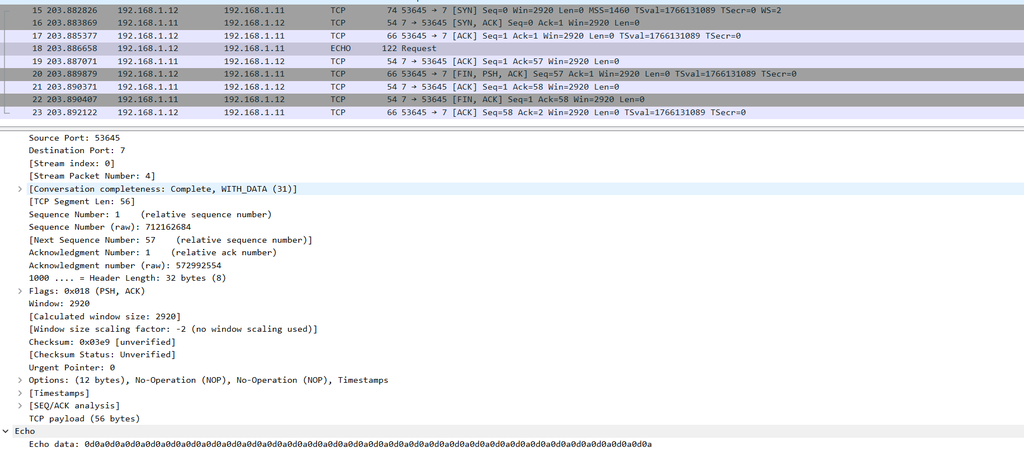

TCP

# Сеть с маршрутизатором FRR

## Топология с FRR

- VPCS
- Ethernet-коммутатор
- Маршрутизатор FRR (шлюз)

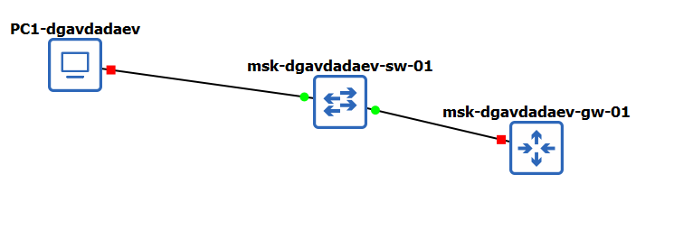

Топология FRR

## Настройка FRR

- Интерфейс eth0: 192.168.1.1/24
- Интерфейс активирован
- Конфигурация сохранена

[figure not shown]

Настройка FRR

## Проверка связности (FRR)

- PC1 успешно отправляет ICMP-запросы на 192.168.1.1
- Связь подтверждена
- Ошибок маршрутизации не выявлено

[figure not shown]

Ping FRR

## Анализ трафика (FRR)

- ARP-разрешение адреса шлюза
- Последующий обмен ICMP-пакетами
- Корректная работа маршрутизатора подтверждена

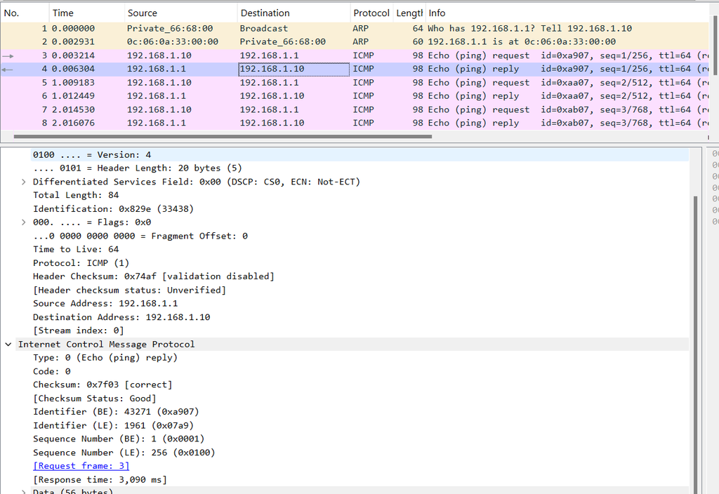

Wireshark FRR

# Сеть с маршрутизатором VyOS

## Топология с VyOS

- VPCS
- Ethernet-коммутатор
- Маршрутизатор VyOS

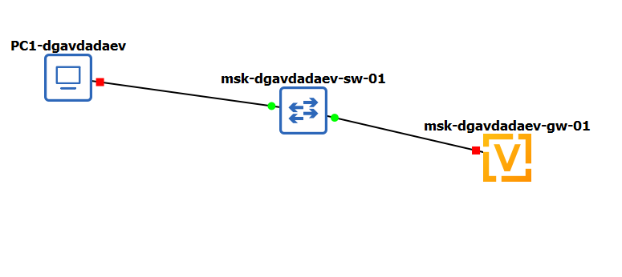

Топология VyOS

## Настройка VyOS

- Задано имя устройства
- Интерфейс eth0: 192.168.1.1/24
- DHCP отключён
- Конфигурация применена и сохранена

[figure not shown]

Настройка VyOS

## Проверка связности (VyOS)

- Успешные ICMP Echo Reply
- Маршрутизатор функционирует как шлюз
- Сетевая связность подтверждена

[figure not shown]

Ping VyOS

## Анализ трафика (VyOS)

- ARP-запросы и ответы
- ICMP Echo Request / Reply
- Корректная обработка пакетов маршрутизатором

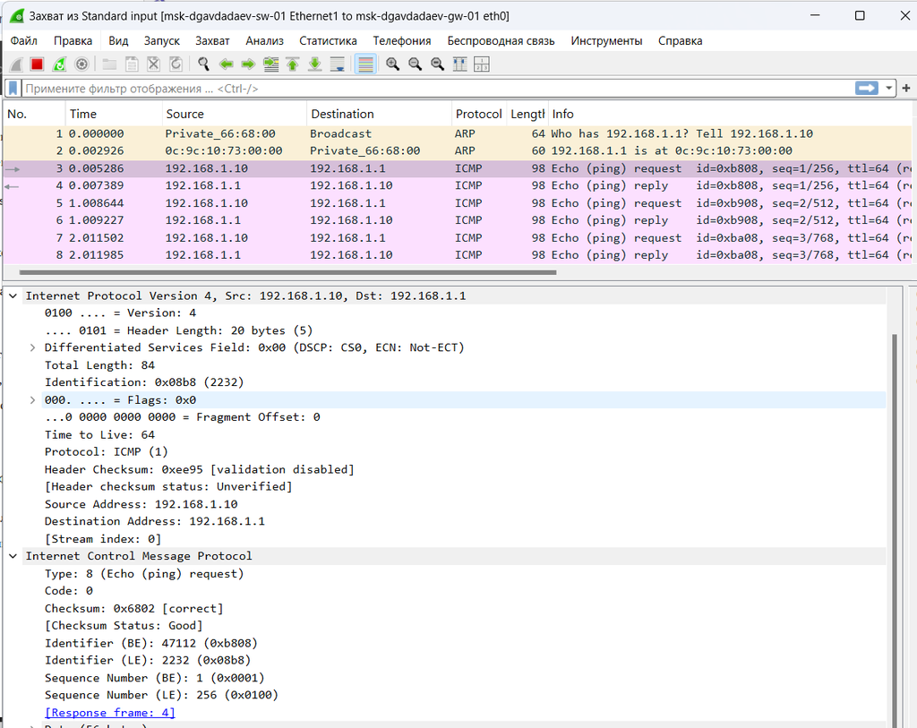

Wireshark VyOS

# Итоги работы

## Выводы

- Освоено моделирование сетей в GNS3
- Настроены:
  - коммутатор
  - VPCS
  - маршрутизаторы FRR и VyOS
- Проанализированы протоколы:
  - ARP
  - ICMP
  - UDP
  - TCP